# PM 566: Homework 03

Author

Tarun Mahesh

# Initial Setup

```r
suppressPackageStartupMessages({
  library(scales)
  library(kableExtra)
  library(forcats)
  library(ggraph)
  library(igraph)
  library(ggridges)
  library(patchwork)
  library(tidytext)
  library(dplyr)
  library(tidyr)
})

from_pubmed <- "https://raw.githubusercontent.com/USCbiostats/data-science-data/master/03_pubmed/pubmed.csv"

pubmed_data <- readr::read_csv(from_pubmed, show_col_types = FALSE) |>
  select(term, abstract) |>
  mutate(abstract_id = row_number())
```

# Text Mining

## Question 1

How many abstracts are associated with each search term? Tokenize the abstracts and count the number of each token. Do you see anything interesting? What are the 5 most common tokens for each search term?

For this question, this is my strategy:

1. Count abstracts by term (using *count*)
2. Tokenize each abstract into single words (using *unnest_tokens*)
3. Count token frequencies within each term (using *count*)
4. List the top 5 tokens per term without removing the stop words (using *group by* and *slice max*)

```r
absperterm <- pubmed_data |>
  count(term, name = "Number of Abstracts") |>
  arrange(desc(`Number of Abstracts`))

absperterm |>
  kable(format = "html", caption = "Abstracts per Search Term") |>
  kable_styling(full_width = FALSE, bootstrap_options = c("striped","hover"))
```

Abstracts per Search Term

| term | Number of Abstracts |
| --- | --- |
| covid | 981 |
| prostate cancer | 787 |
| preeclampsia | 780 |
| cystic fibrosis | 376 |
| meningitis | 317 |

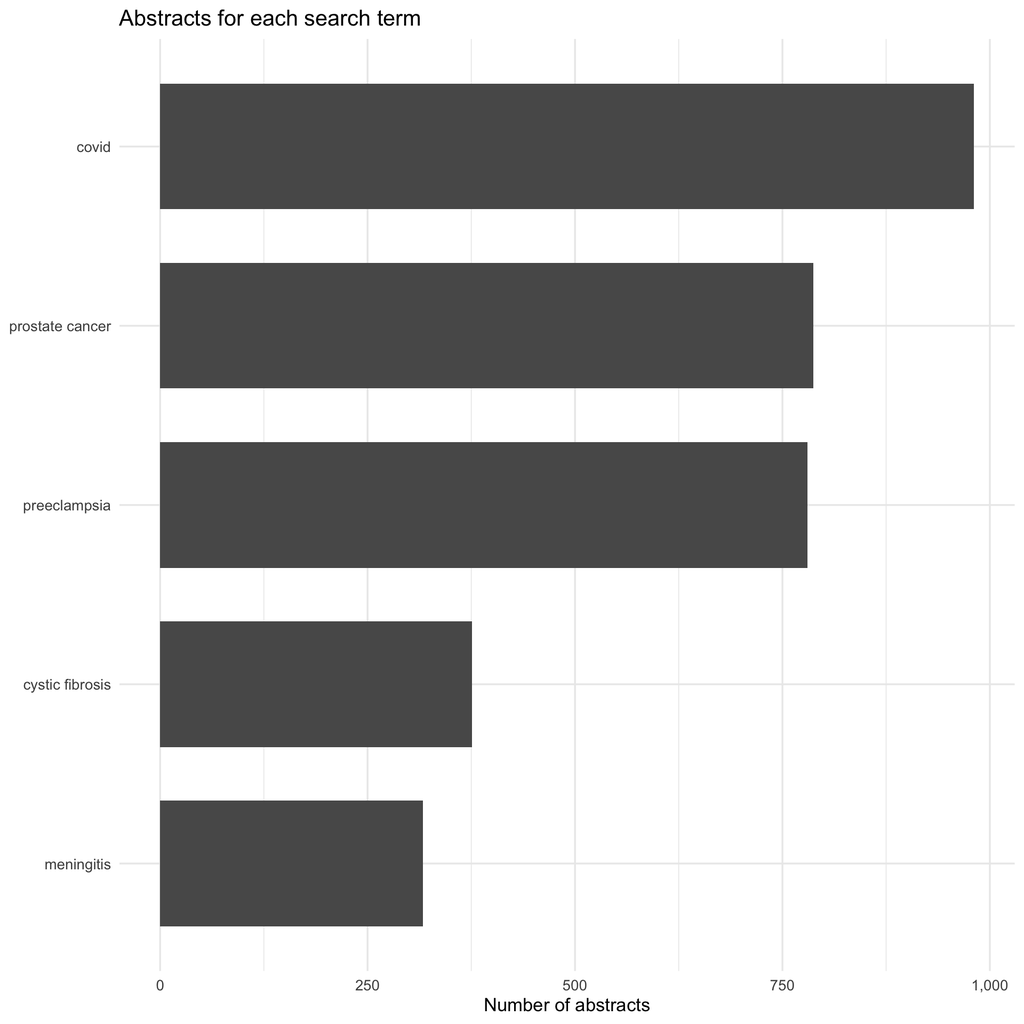

```r
absperterm |>
  ggplot(aes(y = fct_reorder(term, `Number of Abstracts`),
             x = `Number of Abstracts`)) +
  geom_col(width = 0.7) +
  scale_x_continuous(labels = comma) +
  labs(y = NULL, x = "Number of abstracts",
       title = "Abstracts for each search term") +
  theme_minimal(base_size = 13)
```

```r
tokens <- pubmed_data |> unnest_tokens(token, abstract)

counts <- tokens |> count(term, token, sort = TRUE)

top5 <- counts |>
  group_by(term) |> slice_max(n, n = 5, with_ties = FALSE) |> ungroup()

top5 |>
  arrange(term, desc(n)) |> group_by(term) |>
  mutate(rank = row_number()) |> ungroup() |>
  select(term, rank, token, n) |>
  kable("html", caption = "Top 5 Tokens per Term") |>
  kable_styling(full_width = FALSE, bootstrap_options = c("striped","hover")) |> collapse_rows(columns = 1)
```

Top 5 Tokens per Term

| term | rank | token | n |
| --- | --- | --- | --- |
| covid | 1 | the | 9741 |
|  | 2 | of | 7668 |
|  | 3 | covid | 7275 |
|  | 4 | 19 | 7035 |
|  | 5 | and | 6861 |
| cystic fibrosis | 1 | the | 2677 |
|  | 2 | of | 2304 |
|  | 3 | and | 1777 |
|  | 4 | in | 1497 |
|  | 5 | to | 1011 |
| meningitis | 1 | the | 2489 |
|  | 2 | of | 2269 |
|  | 3 | and | 1683 |
|  | 4 | in | 1322 |
|  | 5 | a | 830 |
| preeclampsia | 1 | the | 7119 |
|  | 2 | of | 6837 |
|  | 3 | and | 5255 |
|  | 4 | in | 3869 |
|  | 5 | to | 2651 |
| prostate cancer | 1 | the | 6100 |
|  | 2 | of | 5682 |
|  | 3 | and | 4417 |
|  | 4 | cancer | 3840 |
|  | 5 | prostate | 3832 |

The dataset is heavily weighted towards covid abstracts. Before removing the stop words, words like “the”, “of”, “and” etc. dominate. But what’s interesting, is that some tokens are so strong that they domante over the stop words, like “covid” and “19”. The sheer volume of covid abstracts and the dominance of the “covid” and “19” tokens reinforces the impact the pandemic had on the scientific community and the world as a whole.

## Question 2

Does removing stop words change what tokens appear as the most frequent? What are the 5 most common tokens for each search term after removing stop words?

For this question, this is my strategy:

1. Remove the stop words (using *anti_join(stop_words)*)
2. Recount the tokens per term
3. Return the top 5 tokens per term after cleaning

```r
tokens_nostop <- tokens |>
  anti_join(stop_words, by = c("token" = "word"))

tokencounts_nostop <- tokens_nostop |> count(term, token, sort = TRUE)

top_nostop <- tokencounts_nostop |> group_by(term) |>
  slice_max(n, n = 5, with_ties = FALSE) |> ungroup()

top_nostop |>
  arrange(term, desc(n)) |> group_by(term) |>
  mutate(rank = row_number()) |> ungroup() |>
  select(term, rank, token, n) |>
  kable("html", caption = "Top 5 Tokens per Term (After Stop Words Were Removed)") |>
  kable_styling(full_width = FALSE, bootstrap_options = c("striped","hover")) |> collapse_rows(columns = 1)
```

Top 5 Tokens per Term (After Stop Words Were Removed)

| term | rank | token | n |
| --- | --- | --- | --- |
| covid | 1 | covid | 7275 |
|  | 2 | 19 | 7035 |
|  | 3 | patients | 2293 |
|  | 4 | disease | 943 |
|  | 5 | pandemic | 800 |
| cystic fibrosis | 1 | fibrosis | 867 |
|  | 2 | cystic | 862 |
|  | 3 | cf | 625 |
|  | 4 | patients | 586 |
|  | 5 | disease | 400 |
| meningitis | 1 | patients | 446 |
|  | 2 | meningitis | 429 |
|  | 3 | meningeal | 219 |
|  | 4 | csf | 206 |
|  | 5 | clinical | 187 |
| preeclampsia | 1 | pre | 2038 |
|  | 2 | eclampsia | 2005 |
|  | 3 | preeclampsia | 1863 |
|  | 4 | women | 1196 |
|  | 5 | pregnancy | 969 |
| prostate cancer | 1 | cancer | 3840 |
|  | 2 | prostate | 3832 |
|  | 3 | patients | 934 |
|  | 4 | treatment | 926 |
|  | 5 | disease | 652 |

Removing the stop words drastically changes the most frequent tokens per search term. Now, all tokens are directly related to the search term. These tokens are more informative for further analysis. Some terms are more related to the clinical context than the actual disease, like “patients”.

## Question 3

Tokenize the abstracts into bigrams. Find the 10 most common bigrams and visualize them.

For this question, this is my strategy:

1. Build bigrams (using *(unnest_ngrams)*)
2. Split into word 1 and 2
3. Drop the bigrams that have stop words on either side (using *filter*)
4. Count the frequencies
5. Print the Top 10 bigrams
6. Plot them (using *ggplot*, *forcats* and *fct_reorder*)

```r
bigrams <- pubmed_data |>
  unnest_ngrams(ngram, abstract, n = 2) |>
  separate(ngram, into = c("word_1", "word_2"), sep = " ")

bigrams_filter <- bigrams |>
  filter(!word_1 %in% stop_words$word, !word_2 %in% stop_words$word)

top10_bigrams <- bigrams_filter |>
  count(word_1, word_2, sort = TRUE) |>
  mutate(bigram = paste(word_1, word_2)) |> slice_head(n = 10) |>
  select(bigram, n)

top10_bigrams |>
  kable(format = "html", caption = "Top 10 Bigrams") |>
  kable_styling(full_width = FALSE, bootstrap_options = c("striped","hover"))
```

Top 10 Bigrams

| bigram | n |
| --- | --- |
| covid 19 | 6969 |
| prostate cancer | 3222 |
| pre eclampsia | 1854 |
| cystic fibrosis | 860 |
| 19 patients | 447 |
| 19 pandemic | 419 |
| coronavirus disease | 361 |
| 95 ci | 322 |
| sars cov | 317 |
| cov 2 | 299 |

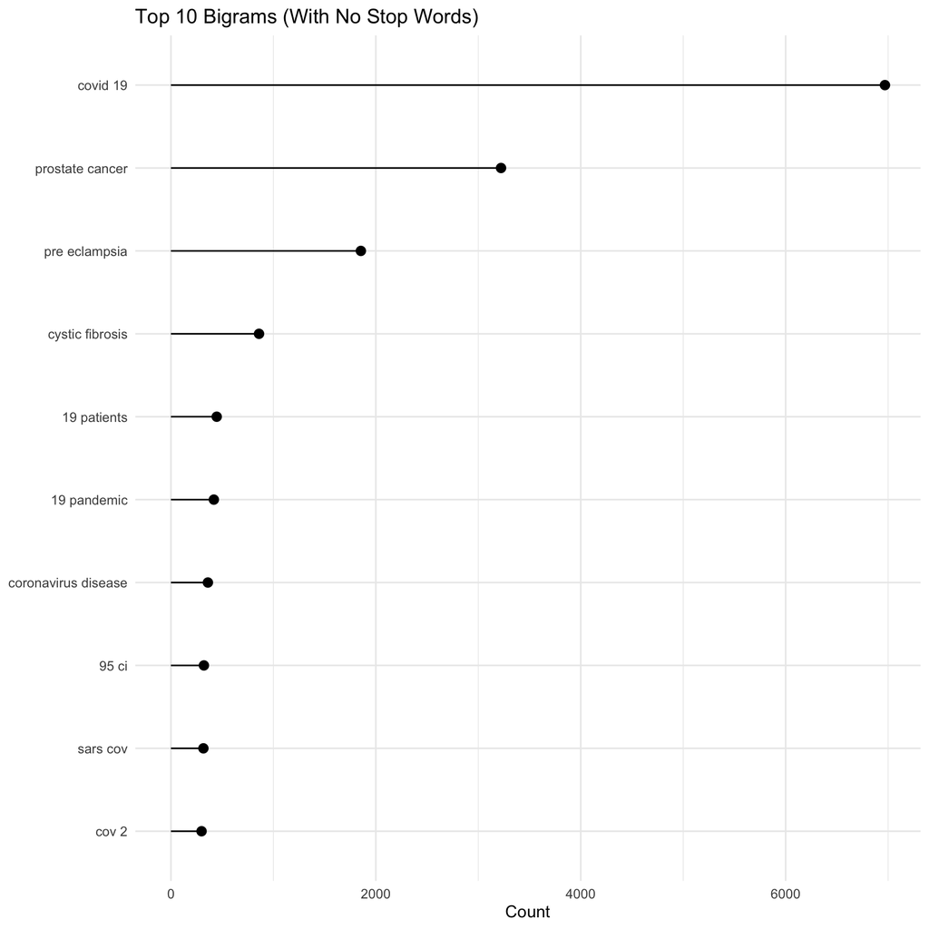

```r
top10_bigrams |>
  mutate(bigram = fct_reorder(bigram, n)) |> ggplot(aes(n, bigram)) +
  geom_segment(aes(x = 0, xend = n, y = bigram, yend = bigram)) +
  geom_point(size = 3) + labs(x = "Count", y = NULL, title = "Top 10 Bigrams (With No Stop Words)") +
  theme_minimal(base_size = 13)
```

The most common bigrams are the disease names themselves, which reinforces the cohesiveness between the search terms and the abstracts the search returns. 95 ci is really interesting here because it is a statistical term (95% confidence interval). It seems like many abstracts report statistical significance. Some virology terms (SARS COV 2) are typically trigrams so they get split into their constituent bigrams, “sars cov” and “cov 2”.

## Question 4

Calculate the TF-IDF value for each word-search term combination (here you want the search term to be the “document”). What are the 5 tokens from each search term with the highest TF-IDF value? How are the results different from the answers you got in Question 1?

For this question, this is my strategy:

1. Treat each search *term* as a document
2. Compute TF-IDF for every (term, token)
3. Extract five highest TF-IDF tokens per term

```r
token_counts <- tokens |>
  count(term, token, name = "n")

tf_idf <- token_counts |>
  bind_tf_idf(token, term, n)

top_tfidf <- tf_idf |>
  group_by(term) |> slice_max(tf_idf, n = 5, with_ties = FALSE) |>
  arrange(term, desc(tf_idf)) |> mutate(rank = row_number()) |>
  ungroup() |> select(term, rank, token, tf_idf)

top_tfidf |>
  rename(Term = term, Rank = rank, Token = token, `TF-IDF` = tf_idf) |>
  mutate(`TF-IDF` = round(`TF-IDF`, 4)) |>
  kable("html", caption = "Top Five TF_IDF Tokens per Term") |>
  kable_styling(full_width = FALSE, bootstrap_options = c("striped","hover")) |>
  collapse_rows(columns = 1)
```

Top Five TF_IDF Tokens per Term

| Term | Rank | Token | TF-IDF |
| --- | --- | --- | --- |
| covid | 1 | covid | 0.0597 |
|  | 2 | pandemic | 0.0066 |
|  | 3 | coronavirus | 0.0053 |
|  | 4 | sars | 0.0031 |
|  | 5 | cov | 0.0027 |
| cystic fibrosis | 1 | cf | 0.0117 |
|  | 2 | fibrosis | 0.0090 |
|  | 3 | cystic | 0.0090 |
|  | 4 | cftr | 0.0028 |
|  | 5 | sweat | 0.0027 |
| meningitis | 1 | meningitis | 0.0148 |
|  | 2 | meningeal | 0.0076 |
|  | 3 | pachymeningitis | 0.0051 |
|  | 4 | csf | 0.0040 |
|  | 5 | meninges | 0.0037 |
| preeclampsia | 1 | eclampsia | 0.0230 |
|  | 2 | preeclampsia | 0.0214 |
|  | 3 | pregnancy | 0.0035 |
|  | 4 | maternal | 0.0029 |
|  | 5 | gestational | 0.0022 |
| prostate cancer | 1 | prostate | 0.0502 |
|  | 2 | androgen | 0.0040 |
|  | 3 | psa | 0.0037 |
|  | 4 | prostatectomy | 0.0028 |
|  | 5 | castration | 0.0019 |

In question 1, we used raw counts, which just outputs word frequency (or token frequency). In this question by using TF-IDF, we essentially reward term-specific vocabulary and down-weigh universally (in our dataset) present tokens. A very obvious effect of TF-IDF weighting is that words like “disease” and “patients” stop showing up, which are not relevant to any one specific disease.

# Sentiment Analysis

## Question 5

Perform a sentiment analysis using the NRC lexicon. What is the most common sentiment for each search term? What if you remove `"positive"` and `"negative"` from the list?

For this question, this is my strategy:

1. Map the tokens to NRC sentiments
2. Count sentiment frequencies within each term
3. Pick the most common sentiment
4. Repeat after removing “positive” and “negative” categories

```r
nrc_sentiments <- get_sentiments("nrc")

tokens_word <- pubmed_data |> unnest_tokens(word, abstract)

nrc_byterm <- tokens_word |>
  inner_join(nrc_sentiments, by = "word") |>
  count(term, sentiment, name = "n") |> group_by(term) |>
  slice_max(n, n = 1, with_ties = FALSE) |> ungroup()

nrc_byterm |>
  rename(Term = term, Sentiment = sentiment, Number = n) |>
  kable("html", caption = "NRC Sentiment per Term") |>
  kable_styling(full_width = FALSE, bootstrap_options = c("striped","hover")) |>
  collapse_rows(columns = 1)
```

NRC Sentiment per Term

| Term | Sentiment | Number |
| --- | --- | --- |
| covid | positive | 9874 |
| cystic fibrosis | positive | 2747 |
| meningitis | negative | 2109 |
| preeclampsia | positive | 8014 |
| prostate cancer | negative | 8918 |

```r
nrc_removed <- nrc_sentiments |>
  filter(!sentiment %in% c("positive", "negative"))

nrc_byterm_removed <- tokens_word |>
  inner_join(nrc_removed, by = "word") |> count(term, sentiment, name = "n") |>
  group_by(term) |> slice_max(n, n = 1, with_ties = FALSE) |> ungroup()

nrc_byterm_removed |>
  rename(Term = term, Sentiment = sentiment, Number = n) |>
  kable("html", caption = "NRC Sentiment per Term (Positive and Negative Removed)") |>
  kable_styling(full_width = FALSE, bootstrap_options = c("striped","hover")) |>
  collapse_rows(columns = 1)
```

NRC Sentiment per Term (Positive and Negative Removed)

| Term | Sentiment | Number |
| --- | --- | --- |
| covid | fear | 7730 |
| cystic fibrosis | disgust | 1714 |
| meningitis | fear | 1510 |
| preeclampsia | anticipation | 4780 |
| prostate cancer | fear | 8118 |

Including “positive” and “negative” collapses nuances into broad and generic terms, but removing them reveals more emotional signals.

The emotion of feart predominates for covid, meningitis and prostate cancer, which is consistent with the serious clinical outcomes of these diseases. Preeclampsia is mapped to anticipation, which suggests that many abstracts discuss monitoring, prediction etc. that is associated with this disease.

## Question 6

Now perform a sentiment analysis using the AFINN lexicon to get an average positivity score for each abstract (hint: you may want to create a variable that indexes, or counts, the abstracts). Create a visualization that shows these scores grouped by search term. Are any search terms noticeably different from the others?

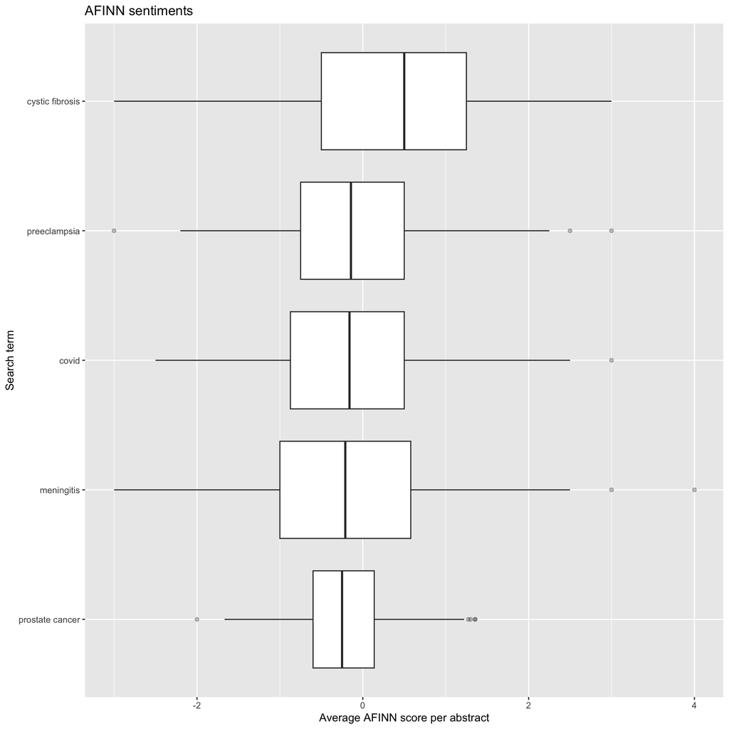

```r
afinn_lexicon <- get_sentiments("afinn")

afinn_scores <- tokens_word |>
  inner_join(afinn_lexicon, by = "word") |> group_by(abstract_id, term) |>
  summarise(avg_afinn = mean(value), .groups = "drop")

afinn_scores <- pubmed_data |>
  select(abstract_id, term) |>
  left_join(afinn_scores, by = c("abstract_id","term"))

afinn_scores |>
  ggplot(aes(x = forcats::fct_reorder(term, avg_afinn, .fun = median, na.rm = TRUE),
             y = avg_afinn)) +
  geom_boxplot(outlier.alpha = 0.3) +
  coord_flip() +
  labs(x = "Search term", y = "Average AFINN score per abstract",
       title = "AFINN sentiments")
```

The position of the boxes in the boxplot (high vs. low medians) indicates ranging between more positive vs more negative average language per abstract for a given term. Interpreting the AFINN lexicon analysis using the context from the previous NRC analysis, it’s reasonable to expect prostate cancer, covid and meningitis to be more negative on average than others, which is validated in the AFINN analysis.

The most noticeable differences are that prostate cancer has more negative sentiments while cystic fibrosis is more positive. The others are roughly neutral on average.